# Exercise 3

1. Getting and reading the .csv file

```r
getwd()
```

```
## [1] "/Users/streetman/IODS-project/data"
```

```r
alc <- read.csv(file = "/Users/streetman/IODS-project/data/alc.csv", header = T, sep=",")
```

```r
library(dplyr)
colnames(alc)
```

```
##  [1] "X"          "school"     "sex"        "age"        "address"
##  [6] "famsize"    "Pstatus"    "Medu"       "Fedu"       "Mjob"
## [11] "Fjob"       "reason"     "nursery"    "internet"   "guardian"
## [16] "traveltime" "studytime"  "failures"   "schoolsup"  "famsup"
## [21] "paid"       "activities" "higher"     "romantic"   "famrel"
## [26] "freetime"   "goout"      "Dalc"       "Walc"       "health"
## [31] "absences"   "G1"         "G2"         "G3"         "alc_use"
## [36] "high_use"
```

The dataset includes the variables above indicating the questions to students relating to their alcohol usage

2. Relationships between high and low alcohol consumption, and choosing the parameters for this exploration

Choosing the parameters

```r
library(tidyr)
glimpse(alc)
```

```
## Observations: 382
## Variables: 36
## $ X          <int> 1, 2, 3, 4, 5, 6, 7, 8, 9, 10, 11, 12, 13, 14, 15, 16…
## $ school     <fct> GP, GP, GP, GP, GP, GP, GP, GP, GP, GP, GP, GP, GP, G…
## $ sex        <fct> F, F, F, F, F, M, M, F, M, M, F, F, M, M, M, F, F, F,…
## $ age        <int> 18, 17, 15, 15, 16, 16, 16, 17, 15, 15, 15, 15, 15, 1…
## $ address    <fct> U, U, U, U, U, U, U, U, U, U, U, U, U, U, U, U, U, U,…
## $ famsize    <fct> GT3, GT3, LE3, GT3, GT3, LE3, LE3, GT3, LE3, GT3, GT3…
## $ Pstatus    <fct> A, T, T, T, T, T, T, A, A, T, T, T, T, T, A, T, T, T,…
## $ Medu       <int> 4, 1, 1, 4, 3, 4, 2, 4, 3, 3, 4, 2, 4, 4, 2, 4, 4, 3,…
## $ Fedu       <int> 4, 1, 1, 2, 3, 3, 2, 4, 2, 4, 4, 1, 4, 3, 2, 4, 4, 3,…
## $ Mjob       <fct> at_home, at_home, at_home, health, other, services, o…
## $ Fjob       <fct> teacher, other, other, services, other, other, other,…
## $ reason     <fct> course, course, other, home, home, reputation, home, …
## $ nursery    <fct> yes, no, yes, yes, yes, yes, yes, yes, yes, yes, yes,…
```

[output cut: 23 more lines]

Hypothesis: there is correlation between the high alcohol consumption and the chosen variables when analyzed in a univariate method to observe correlation H0: there is no correlation between a chosen variable and high alcohol consumption H1: there is significant correlation between a chosen variable and high alcohol consumption

3. Distributions between the chosen variables above and the relations to alcohol consumption

Numerical overview of data

```r
summary(alc)
```

```
##        X          school   sex          age        address famsize
##  Min.   :  1.00   GP:342   F:198   Min.   :15.00   R: 81   GT3:278
##  1st Qu.: 96.25   MS: 40   M:184   1st Qu.:16.00   U:301   LE3:104
##  Median :191.50                    Median :17.00
##  Mean   :191.50                    Mean   :16.59
##  3rd Qu.:286.75                    3rd Qu.:17.00
##  Max.   :382.00                    Max.   :22.00
##  Pstatus      Medu            Fedu             Mjob           Fjob
##  A: 38   Min.   :0.000   Min.   :0.000   at_home : 53   at_home : 16
##  T:344   1st Qu.:2.000   1st Qu.:2.000   health  : 33   health  : 17
##          Median :3.000   Median :3.000   other   :138   other   :211
##          Mean   :2.806   Mean   :2.565   services: 96   services:107
##          3rd Qu.:4.000   3rd Qu.:4.000   teacher : 62   teacher : 31
##          Max.   :4.000   Max.   :4.000
##         reason    nursery   internet    guardian     traveltime
##  course    :140   no : 72   no : 58   father: 91   Min.   :1.000
##  home      :110   yes:310   yes:324   mother:275   1st Qu.:1.000
##  other     : 34                       other : 16   Median :1.000
##  reputation: 98                                    Mean   :1.448
##                                                    3rd Qu.:2.000
##                                                    Max.   :4.000
##    studytime        failures      schoolsup famsup     paid     activities
##  Min.   :1.000   Min.   :0.0000   no :331   no :144   no :205   no :181
##  1st Qu.:1.000   1st Qu.:0.0000   yes: 51   yes:238   yes:177   yes:201
##  Median :2.000   Median :0.0000
##  Mean   :2.037   Mean   :0.2016
##  3rd Qu.:2.000   3rd Qu.:0.0000
##  Max.   :4.000   Max.   :3.0000
##  higher    romantic      famrel         freetime        goout
##  no : 18   no :261   Min.   :1.000   Min.   :1.00   Min.   :1.000
##  yes:364   yes:121   1st Qu.:4.000   1st Qu.:3.00   1st Qu.:2.000
##                      Median :4.000   Median :3.00   Median :3.000
##                      Mean   :3.937   Mean   :3.22   Mean   :3.113
##                      3rd Qu.:5.000   3rd Qu.:4.00   3rd Qu.:4.000
##                      Max.   :5.000   Max.   :5.00   Max.   :5.000
##       Dalc            Walc           health         absences
##  Min.   :1.000   Min.   :1.000   Min.   :1.000   Min.   : 0.0
##  1st Qu.:1.000   1st Qu.:1.000   1st Qu.:3.000   1st Qu.: 1.0
##  Median :1.000   Median :2.000   Median :4.000   Median : 3.0
##  Mean   :1.482   Mean   :2.296   Mean   :3.573   Mean   : 4.5
##  3rd Qu.:2.000   3rd Qu.:3.000   3rd Qu.:5.000   3rd Qu.: 6.0
##  Max.   :5.000   Max.   :5.000   Max.   :5.000   Max.   :45.0
##        G1              G2              G3           alc_use
##  Min.   : 2.00   Min.   : 4.00   Min.   : 0.00   Min.   :1.000
##  1st Qu.:10.00   1st Qu.:10.00   1st Qu.:10.00   1st Qu.:1.000
##  Median :12.00   Median :12.00   Median :12.00   Median :1.500
##  Mean   :11.49   Mean   :11.47   Mean   :11.46   Mean   :1.889
##  3rd Qu.:14.00   3rd Qu.:14.00   3rd Qu.:14.00   3rd Qu.:2.500
##  Max.   :18.00   Max.   :18.00   Max.   :18.00   Max.   :5.000
##   high_use
##  Mode :logical
##  FALSE:268
##  TRUE :114
##
##
##
```

Graphical overview of data

Distribution of the chosen variables

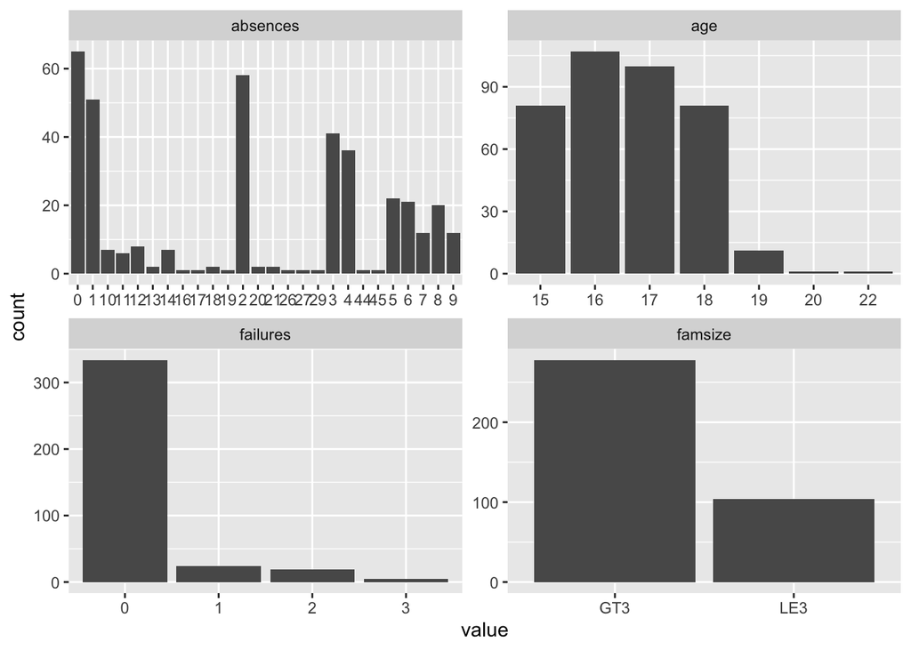

```r
library(tidyr); library(dplyr); library(ggplot2)
alc_selected <- select(alc, one_of(c("age", "famsize", "failures", "absences")))
gather(alc_selected) %>% ggplot(aes(value)) + facet_wrap("key", scales = "free") + geom_bar()
```

Variables vs. alcohol usage by histograms

Age

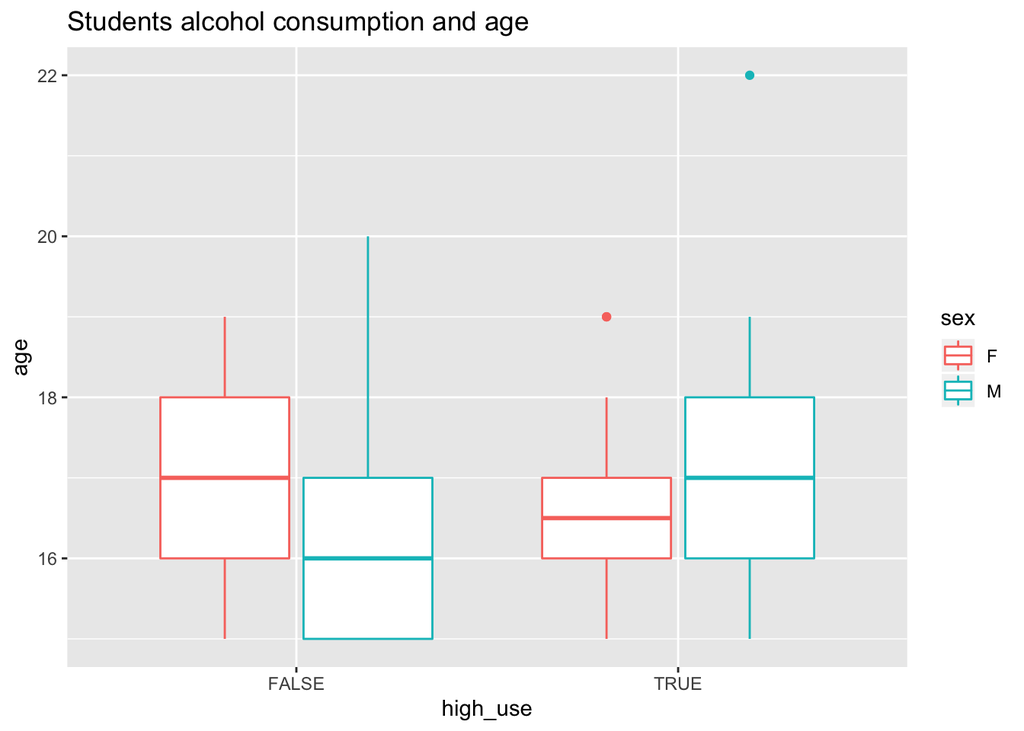

```r
g1 <- ggplot(alc, aes(x = high_use, y = age))
g1 + geom_boxplot(aes(col=sex)) + ylab("age") + ggtitle("Students alcohol consumption and age")
```

Famsize

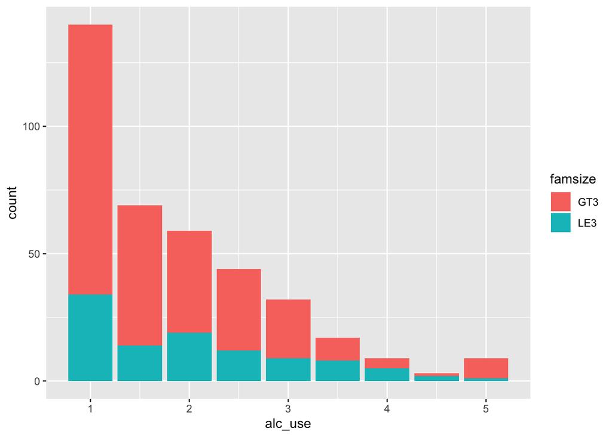

```r
g1 <- ggplot(data = alc, aes(x = alc_use, fill = famsize))
g1 + geom_bar()
```

Failures

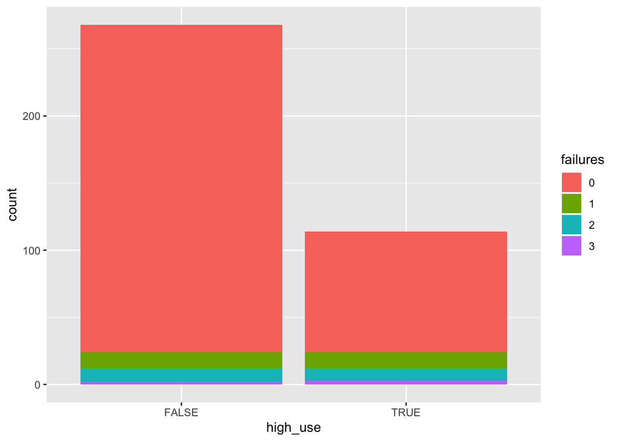

```r
alc$failures <-  as.factor(alc$failures)
g1 <- ggplot(alc, aes(x = high_use, fill = failures))
g1 + geom_bar()
```

Absences

[figure not shown]

```r
g1 <- ggplot(alc, aes(x = high_use, y = absences))
g1 + geom_boxplot(aes(col=sex)) + ylab("age") + ggtitle("Students alcohol consumption and absences")
```

```r
## Fit a linear model
model_fit <- lm(high_use ~ age + famsize + failures + absences, data = alc)

## Print out a summary of the model
summary (model_fit)
```

```
##
## Call:
## lm(formula = high_use ~ age + famsize + failures + absences,
##     data = alc)
##
## Residuals:
##     Min      1Q  Median      3Q     Max
## -0.9637 -0.2895 -0.2121  0.5077  0.8601
##
## Coefficients:
##              Estimate Std. Error t value Pr(>|t|)
## (Intercept) -0.221528   0.327246  -0.677   0.4989
## age          0.024093   0.019855   1.213   0.2257
## famsizeLE3   0.077375   0.051234   1.510   0.1318
## failures1    0.173717   0.095042   1.828   0.0684 .
## failures2    0.191205   0.104979   1.821   0.0693 .
## failures3    0.282834   0.202811   1.395   0.1640
## absences     0.016702   0.004234   3.944 9.55e-05 ***
## ---
## Signif. codes:  0 '***' 0.001 '**' 0.01 '*' 0.05 '.' 0.1 ' ' 1
##
## Residual standard error: 0.4427 on 375 degrees of freedom
## Multiple R-squared:  0.08102,    Adjusted R-squared:  0.06632
## F-statistic:  5.51 on 6 and 375 DF,  p-value: 1.741e-05
```

```r
## Fit a linear model
model_fit <- lm(high_use ~ famsize + failures + absences, data = alc)

## Print out a summary of the model
summary (model_fit)
```

```
##
## Call:
## lm(formula = high_use ~ famsize + failures + absences, data = alc)
##
## Residuals:
##     Min      1Q  Median      3Q     Max
## -0.9516 -0.2773 -0.2081  0.5364  0.8265
##
## Coefficients:
##             Estimate Std. Error t value Pr(>|t|)
## (Intercept) 0.173534   0.033045   5.252 2.53e-07 ***
## famsizeLE3  0.078463   0.051259   1.531   0.1267
## failures1   0.181549   0.094882   1.913   0.0565 .
## failures2   0.202991   0.104595   1.941   0.0530 .
## failures3   0.322723   0.200255   1.612   0.1079
## absences    0.017290   0.004209   4.108 4.90e-05 ***
## ---
## Signif. codes:  0 '***' 0.001 '**' 0.01 '*' 0.05 '.' 0.1 ' ' 1
##
## Residual standard error: 0.443 on 376 degrees of freedom
## Multiple R-squared:  0.07742,    Adjusted R-squared:  0.06515
## F-statistic:  6.31 on 5 and 376 DF,  p-value: 1.221e-05
```

```r
## Fit a linear model
model_fit <- lm(high_use ~ failures + absences, data = alc)

## Print out a summary of the model
summary (model_fit)
```

```
##
## Call:
## lm(formula = high_use ~ failures + absences, data = alc)
##
## Residuals:
##     Min      1Q  Median      3Q     Max
## -0.9859 -0.2777 -0.2117  0.5278  0.8059
##
## Coefficients:
##             Estimate Std. Error t value Pr(>|t|)
## (Intercept) 0.194067   0.030253   6.415 4.23e-10 ***
## failures1   0.171754   0.094834   1.811   0.0709 .
## failures2   0.210155   0.104676   2.008   0.0454 *
## failures3   0.300350   0.200076   1.501   0.1341
## absences    0.017597   0.004212   4.178 3.66e-05 ***
## ---
## Signif. codes:  0 '***' 0.001 '**' 0.01 '*' 0.05 '.' 0.1 ' ' 1
##
## Residual standard error: 0.4438 on 377 degrees of freedom
## Multiple R-squared:  0.07167,    Adjusted R-squared:  0.06182
## F-statistic: 7.276 on 4 and 377 DF,  p-value: 1.185e-05
```

Odds rations and CI

```r
### Fitting the logistic regressio model
m <- glm(high_use ~ failures + absences, data = alc, family = "binomial")

### Compute odds ratios (OR)
OR <- coef(m) %>% exp

### Compute confidence intervals (CI)
CI <- confint(m) %>% exp
### Printing the output
cbind(OR, CI)
```

```
##                    OR     2.5 %     97.5 %
## (Intercept) 0.2510728 0.1798228  0.3440709
## failures1   2.1349534 0.8742434  5.1529322
## failures2   2.5703176 0.9781096  6.6694739
## failures3   3.6804549 0.5772189 29.1101887
## absences    1.0878039 1.0420798  1.1406595
```

5. Predictive power of LR model

```r
## Fit the model
m <- glm(high_use ~ failures + absences, data = alc, family = "binomial")

## Predict() the probability of high_use
probabilities <- predict(m, type = "response")

## Add the predicted probabilities to 'alc'
alc <- mutate(alc, probability = probabilities)

## Use the probabilities to make a prediction of high_use
alc <- mutate(alc, prediction = probability > 0.5)

## Tabulate the target variable versus the predictions
results <- table(high_use = alc$high_use, prediction = alc$prediction)

results
```

```
##         prediction
## high_use FALSE TRUE
##    FALSE   256   12
##    TRUE     99   15
```

```r
tab <- table(high_use = alc$high_use, prediction = alc$prediction) %>% prop.table() %>% addmargins()

tab
```

```
##         prediction
## high_use      FALSE       TRUE        Sum
##    FALSE 0.67015707 0.03141361 0.70157068
##    TRUE  0.25916230 0.03926702 0.29842932
##    Sum   0.92931937 0.07068063 1.00000000
```

```r
## Total proportion of inaccurately classified individuals
loss_func <- function(class, prob) {
  n_wrong <- abs(class - prob) > 0.5
  mean(n_wrong)
}

loss_func(class = alc$high_use, prob = alc$probability)
```

```
## [1] 0.2905759
```